jupyter nbconvert SLIDES.ipynb -to slides --post serve

# Pyday Murcia 2016

```python
from IPython.display import display
from IPython.display import Image, HTML
import numpy as np
import matplotlib.pyplot as plt

np.random.seed(42)
```

```python
%pylab inline
```

**¿QUÉ ES DATA SCIENCE (CIENCIA DE DATOS)?**

[figure not shown]

# Data Science - El proceso

[figure not shown]

El proceso básico es obtener datos, analizarlos y lo más importante, aprovechar los datos.

### Areas principales

- Análisis de datos
- Machine Learning
- Visualización de Datos
- Big Data

[figure not shown]

## Herramientas

- Ingles
- Python (o R, o Java) (pero Python > R > Java)
- Jupyter Notebook
- Sistemas Unix
- Git

# Jupyter Notebook

https://www.youtube.com/watch?v=-gOZhQcKxs8

# UNIX

[figure not shown]

http://www.tutorialesytrucos.com/tutoriales/24-tutorial-de-unix.html

# GIT

[figure not shown]

http://www.github.com

http://www.bitbucket.org

http://blog.santiagobasulto.com.ar/programacion/2011/11/27/tutorial-de-git-en-espanol.html

## Módulos

- **Fundamentos y Estadística**
  - Numpy
  - StatsModels
  - Scipy
- **Análisis y Procesado de Datos**
  - Numpy
  - Pandas
- **Machine Learning**
  - Scikit-Learn
  - TensorFlow
- **NLP (Procesado de Lenguaje Natural)**
  - NLTK
- **Big Data**
  - Spark

# Tutoriales

http://pybonacci.org/2015/01/14/introduccion-a-machine-learning-con-python-parte-1/

# Recursos

Pybonacci

```python
Recursos
```

**MACHINE LEARNING**

```python
HTML('<iframe src=http://en.mobile.wikipedia.org/wiki/Machine_learning?useformat=mobile width=1000 height=350></iframe>')
```

[interactive chart not shown]

**Machine Learning Tools**

Choose your prefered option here https://github.com/josephmisiti/awesome-machine-learning

**TYPES OF ML SOLUTIONS**

```python
Image('ml_types.png')
```

[output not shown]

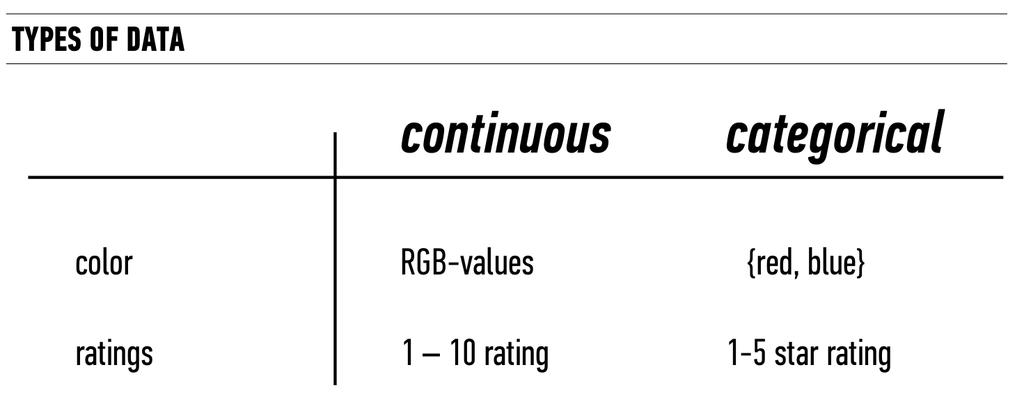

```python
Image('data_types.png')
```

**ML TYPE GOALS**

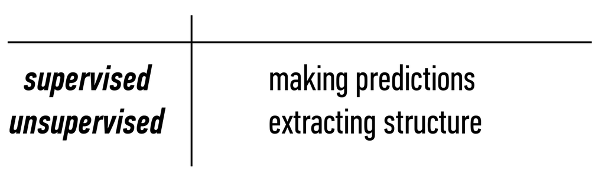

```python
Image('ml_type_goals.png')
```

**ML Models** *(or choose your own adventure)*

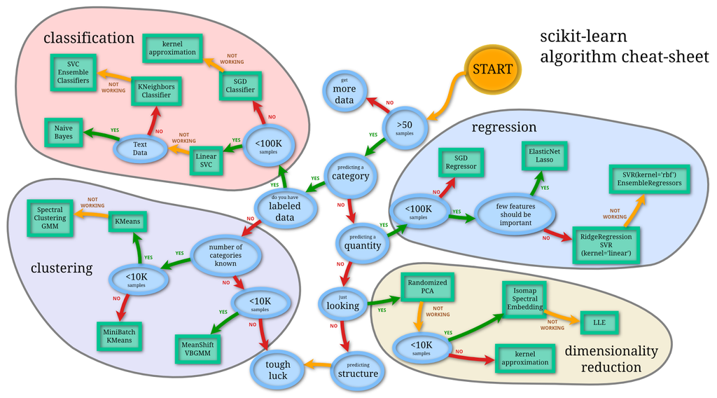

```python
Image('choose_your_own_adventure.png')
```

**Classification**

```python
HTML('<iframe src=http://en.mobile.wikipedia.org/wiki/Statistical_classification?useformat=mobile width=700 height=350></iframe>')
```

[interactive chart not shown]

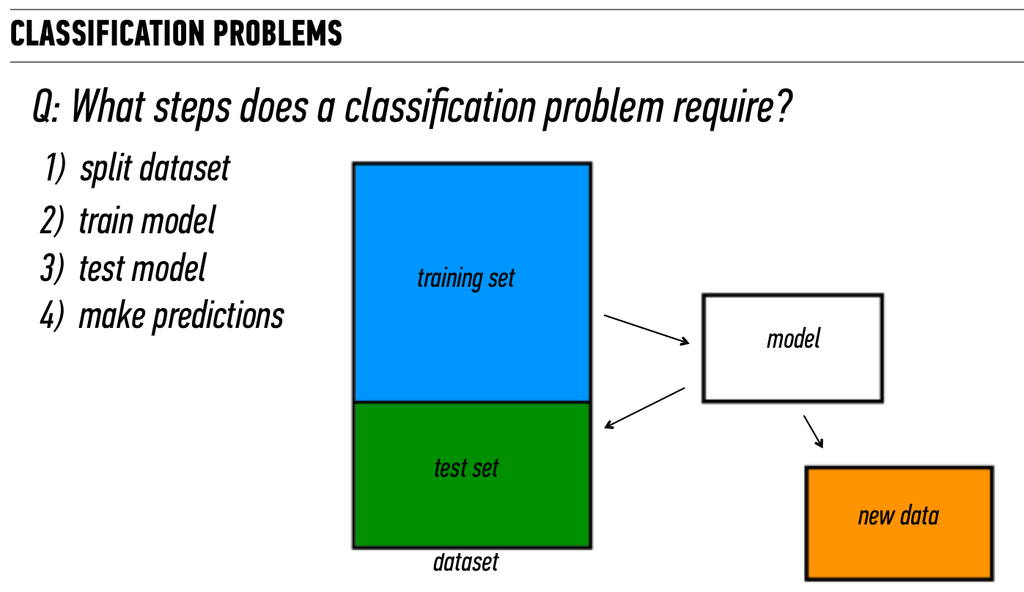

```python
Image('classification.png')
```

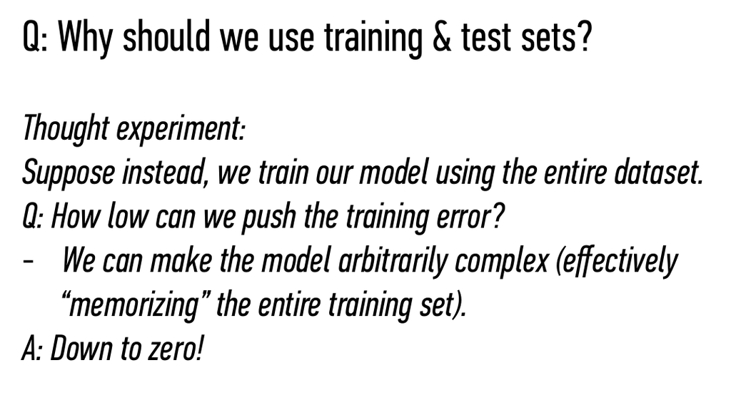

```python
Image('training_test1.png')
```

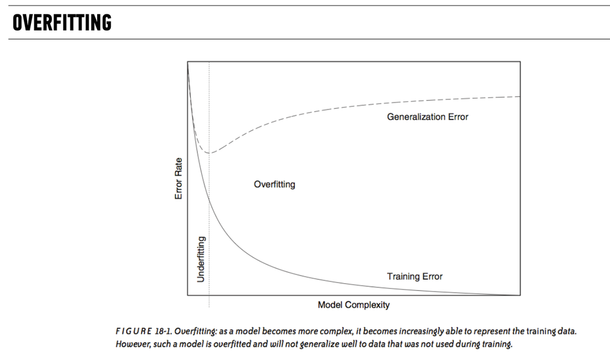

```python
Image('training_test2.png')
```

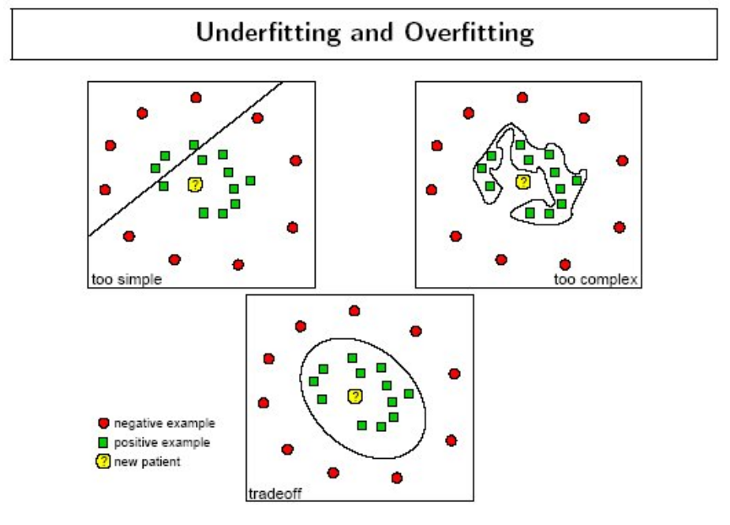

```python
Image('training_test3.png')
```

```python
#Let's load the standard Iris Dataset
from sklearn import datasets
iris = datasets.load_iris()

iris_dataset = pd.DataFrame(iris.data, columns=iris.feature_names)
iris_dataset['target'] = map(lambda x: iris.target_names[x], iris.target)
```

```python
print(iris.DESCR)
Image(url='iris.gif')
```

```
Iris Plants Database

Notes
-----
Data Set Characteristics:
    :Number of Instances: 150 (50 in each of three classes)
    :Number of Attributes: 4 numeric, predictive attributes and the class
    :Attribute Information:
        - sepal length in cm
        - sepal width in cm
        - petal length in cm
        - petal width in cm
        - class:
                - Iris-Setosa
                - Iris-Versicolour
                - Iris-Virginica
    :Summary Statistics:
    ============== ==== ==== ======= ===== ====================
                    Min  Max   Mean    SD   Class Correlation
    ============== ==== ==== ======= ===== ====================
    sepal length:   4.3  7.9   5.84   0.83    0.7826
    sepal width:    2.0  4.4   3.05   0.43   -0.4194
    petal length:   1.0  6.9   3.76   1.76    0.9490  (high!)
    petal width:    0.1  2.5   1.20  0.76     0.9565  (high!)
    ============== ==== ==== ======= ===== ====================
    :Missing Attribute Values: None
    :Class Distribution: 33.3% for each of 3 classes.
    :Creator: R.A. Fisher
    :Donor: Michael Marshall (MARSHALL%PLU@io.arc.nasa.gov)
    :Date: July, 1988

This is a copy of UCI ML iris datasets.
http://archive.ics.uci.edu/ml/datasets/Iris

The famous Iris database, first used by Sir R.A Fisher

This is perhaps the best known database to be found in the
pattern recognition literature.  Fisher's paper is a classic in the field and
is referenced frequently to this day.  (See Duda & Hart, for example.)  The
data set contains 3 classes of 50 instances each, where each class refers to a
type of iris plant.  One class is linearly separable from the other 2; the
latter are NOT linearly separable from each other.

References
----------
   - Fisher,R.A. "The use of multiple measurements in taxonomic problems"
     Annual Eugenics, 7, Part II, 179-188 (1936); also in "Contributions to
     Mathematical Statistics" (John Wiley, NY, 1950).
   - Duda,R.O., & Hart,P.E. (1973) Pattern Classification and Scene Analysis.
     (Q327.D83) John Wiley & Sons.  ISBN 0-471-22361-1.  See page 218.
   - Dasarathy, B.V. (1980) "Nosing Around the Neighborhood: A New System
     Structure and Classification Rule for Recognition in Partially Exposed
     Environments".  IEEE Transactions on Pattern Analysis and Machine
     Intelligence, Vol. PAMI-2, No. 1, 67-71.
   - Gates, G.W. (1972) "The Reduced Nearest Neighbor Rule".  IEEE Transactions
     on Information Theory, May 1972, 431-433.
   - See also: 1988 MLC Proceedings, 54-64.  Cheeseman et al"s AUTOCLASS II
     conceptual clustering system finds 3 classes in the data.
   - Many, many more ...
```

[figure not shown]

```python
iris_dataset.head()
```

|  | sepal length (cm) | sepal width (cm) | petal length (cm) | petal width (cm) | target |
| --- | --- | --- | --- | --- | --- |
| 0 | 5.1 | 3.5 | 1.4 | 0.2 | setosa |
| 1 | 4.9 | 3.0 | 1.4 | 0.2 | setosa |
| 2 | 4.7 | 3.2 | 1.3 | 0.2 | setosa |
| 3 | 4.6 | 3.1 | 1.5 | 0.2 | setosa |
| 4 | 5.0 | 3.6 | 1.4 | 0.2 | setosa |

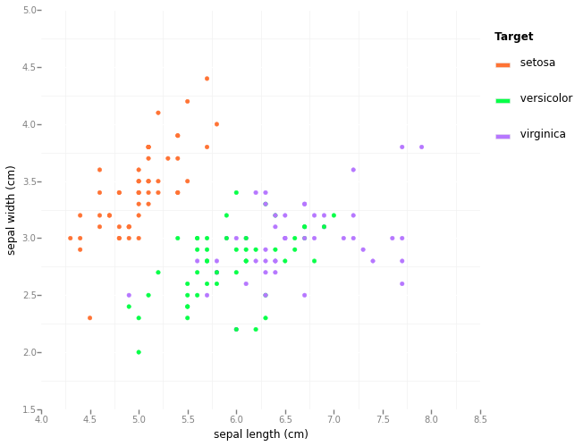

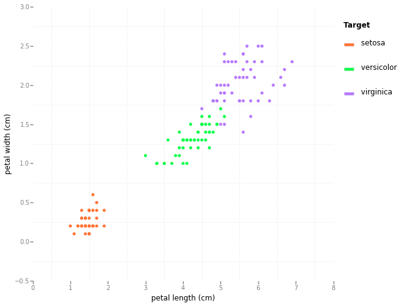

```python
from ggplot import *

print(ggplot(aes(x='sepal length (cm)', y='sepal width (cm)', colour='target'),data=iris_dataset) + geom_point()+theme_bw())
print(ggplot(aes(x='petal length (cm)', y='petal width (cm)', colour='target'),data=iris_dataset) + geom_point()+theme_bw())
```

**Model: K-Nearest Neighbours**

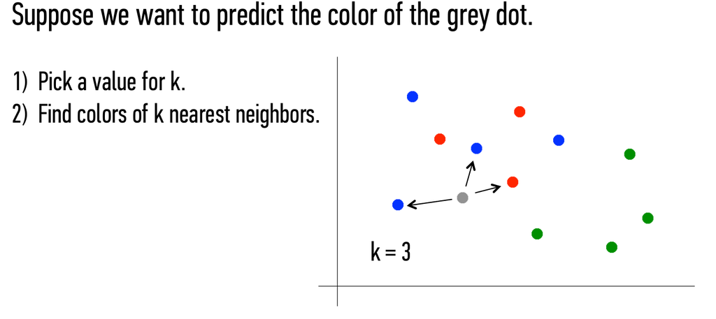

```python
Image('knn.png')
```

```python
from sklearn.neighbors import KNeighborsClassifier
neigh = KNeighborsClassifier(n_neighbors=3)
```

```python
#We fit the model to the data
neigh.fit(iris.data, iris.target)
```

```
KNeighborsClassifier(algorithm='auto', leaf_size=30, metric='minkowski',
           n_neighbors=3, p=2, weights='uniform')
```

```python
#Now we predict using that model with the existing data
predicted_class = neigh.predict(iris.data)
```

```
[[50  0  0]
 [ 0 47  3]
 [ 0  3 47]]
```

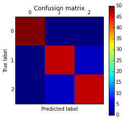

```python
from sklearn.metrics import confusion_matrix
import pylab as pl

cm = confusion_matrix(iris.target, predicted_class)
print(cm)
pl.matshow(cm)
pl.title('Confusion matrix')
pl.colorbar()
pl.ylabel('True label')
pl.xlabel('Predicted label')
pl.show()
```

**REGRESSION**

```python
Image('ml_types.png')
```

[output not shown]

**REGRESSION EXAMPLE - The Boston Housing Dataset**

```python
from sklearn.datasets import load_boston
boston = load_boston()
boston_dataset = pd.DataFrame(boston.data, columns=boston.feature_names[:-1])
boston_dataset['target'] = boston.target
```

```python
print(boston.DESCR)
```

```
Boston House Prices dataset

Notes
------
Data Set Characteristics:

    :Number of Instances: 506

    :Number of Attributes: 13 numeric/categorical predictive

    :Median Value (attribute 14) is usually the target

    :Attribute Information (in order):
        - CRIM     per capita crime rate by town
        - ZN       proportion of residential land zoned for lots over 25,000 sq.ft.
        - INDUS    proportion of non-retail business acres per town
        - CHAS     Charles River dummy variable (= 1 if tract bounds river; 0 otherwise)
        - NOX      nitric oxides concentration (parts per 10 million)
        - RM       average number of rooms per dwelling
        - AGE      proportion of owner-occupied units built prior to 1940
        - DIS      weighted distances to five Boston employment centres
        - RAD      index of accessibility to radial highways
        - TAX      full-value property-tax rate per $10,000
        - PTRATIO  pupil-teacher ratio by town
        - B        1000(Bk - 0.63)^2 where Bk is the proportion of blacks by town
        - LSTAT    % lower status of the population
        - MEDV     Median value of owner-occupied homes in $1000's

    :Missing Attribute Values: None

    :Creator: Harrison, D. and Rubinfeld, D.L.

This is a copy of UCI ML housing dataset.
http://archive.ics.uci.edu/ml/datasets/Housing


This dataset was taken from the StatLib library which is maintained at Carnegie Mellon University.

The Boston house-price data of Harrison, D. and Rubinfeld, D.L. 'Hedonic
prices and the demand for clean air', J. Environ. Economics & Management,
vol.5, 81-102, 1978.   Used in Belsley, Kuh & Welsch, 'Regression diagnostics
...', Wiley, 1980.   N.B. Various transformations are used in the table on
pages 244-261 of the latter.

The Boston house-price data has been used in many machine learning papers that address regression
problems.

**References**

   - Belsley, Kuh & Welsch, 'Regression diagnostics: Identifying Influential Data and Sources of Collinearity', Wiley, 1980. 244-261.
   - Quinlan,R. (1993). Combining Instance-Based and Model-Based Learning. In Proceedings on the Tenth International Conference of Machine Learning, 236-243, University of Massachusetts, Amherst. Morgan Kaufmann.
   - many more! (see http://archive.ics.uci.edu/ml/datasets/Housing)
```

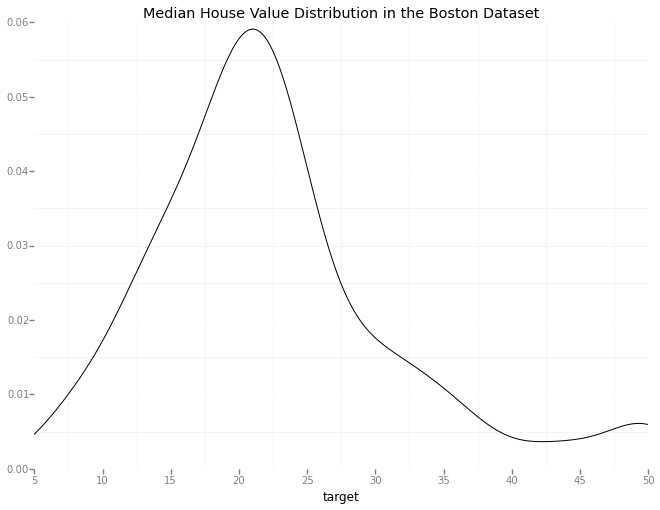

```python
ggplot(aes(x='target'), data=boston_dataset) + geom_density() +ggtitle('Median House Value Distribution in the Boston Dataset') + theme_bw()
```

**Linear Regression**

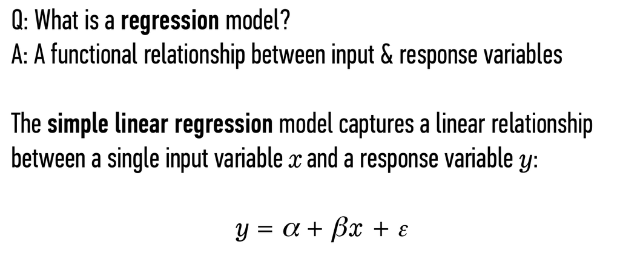

```python
Image('regression1.png')
```

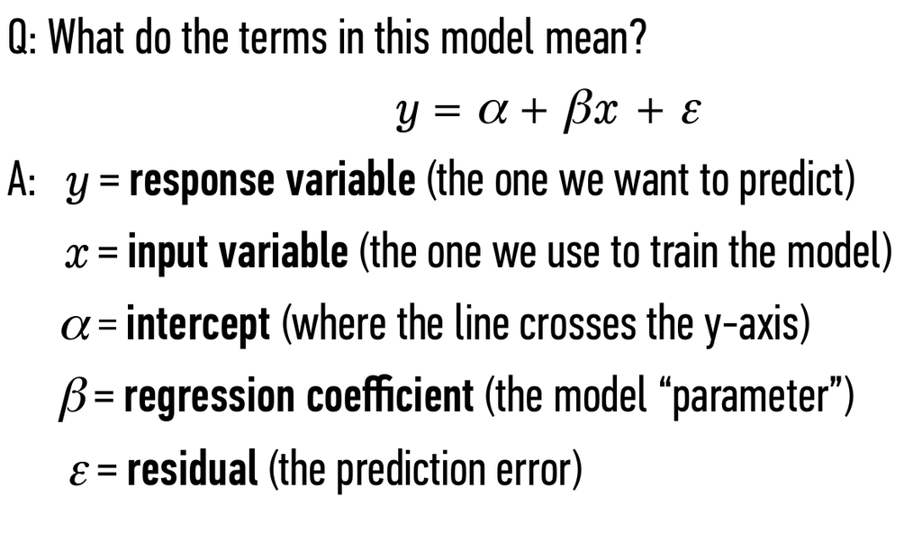

```python
Image('regression2.png')
```

**Linear Regression's goal is to minimize the Ordinary Least Squared Residuals (OLS)**

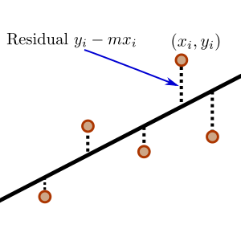

```python
Image('Residuals.png')
```

**Lets do a train-test split this time**

```python
split = int(round(len(boston.data) * 0.7))

train_data = boston.data[:split]
train_price = boston.target[:split]

test_data = boston.data[split:]
test_price = boston.target[split:]
```

```python
from sklearn.linear_model import LinearRegression

#Instantiate the classifier
clf = LinearRegression()
#fit the data to the model
clf.fit(train_data, train_price)
#predict
predicted_train_prices = clf.predict(train_data)
```

**How do we measure success?. Each case and model requires different metrics, but a common regression metric is the Mean Absolute Error**

```python
from sklearn.metrics import mean_absolute_error
train_error = mean_absolute_error(train_price, predicted_train_prices)
print('TRAINING ERROR: {}'.format(train_error))
```

```
TRAINING ERROR: 2.30724619528
```

**HOW ABOUT THE TEST ERROR (GENERALIZATION ERROR)**

```python
#predict
predicted_test_prices = clf.predict(test_data)
test_error = mean_absolute_error(test_price, predicted_test_prices)
print('TEST ERROR: {}'.format(test_error))
```

```
TEST ERROR: 15.3080542627
```

**ONE WAY TO MINIMIZE THE MISCALCULATION DUE TO A SINGLE SPLIT IS TO DO MULTIPLE RANDOM SPLITS AND COMPUTE THE OVERALL ERROR**

**THIS IS CALLED CROSS-VALIDATION** *(n-fold cross-validation)*

```python
from sklearn.cross_validation import cross_val_score
clf = LinearRegression()
scores = cross_val_score(clf, boston.data, boston.target, cv=50, score_func=mean_absolute_error)
print(scores)
print('\nCROSS-VALIDATED ERROR FOR LINEAR REGRESSION MODEL: {}'.format(mean(scores)))
```

```
[  4.38875243   1.56983556   1.27463855   1.42160349   2.44220705
   3.09487876   1.55490243   1.77182458   4.23071364   2.51338047
   2.48877306   1.52990582   1.46275323   2.87789343   3.6730029
   5.68428464   4.31281197   4.2746291    4.20302468   3.89012905
   3.22874196   5.12899573   3.46462619   3.8176626    3.5706779
   4.3970238    3.42065944   3.0768021    2.9168777    3.30434645
   3.95602261   0.9939885    1.82515664   2.38184107   3.98147552
   5.22306668  19.5245849    4.87938331   4.03969372   6.07445829
   6.98880021   3.46618075   4.73593203   1.69294506   3.68833169
   1.53352289   2.47670083   2.10758288   3.12552609   3.55905149]

CROSS-VALIDATED ERROR FOR LINEAR REGRESSION MODEL: 3.62481207759
```

**CLUSTERING**

```python
Image('ml_types.png')
```

[output not shown]

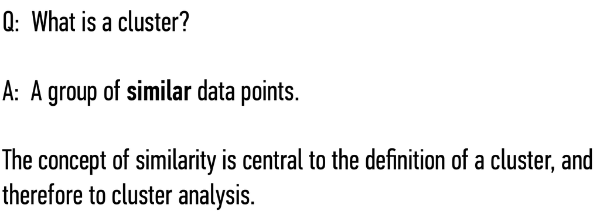

```python
Image('clustering1.png')
```

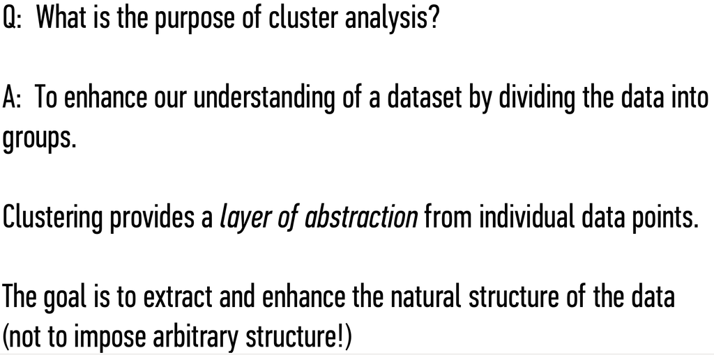

```python
Image('clustering2.png')
```

**Clustering - K-Means clustering**

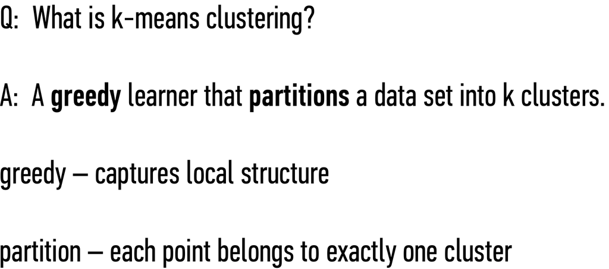

```python
Image('kmeans.png')
```

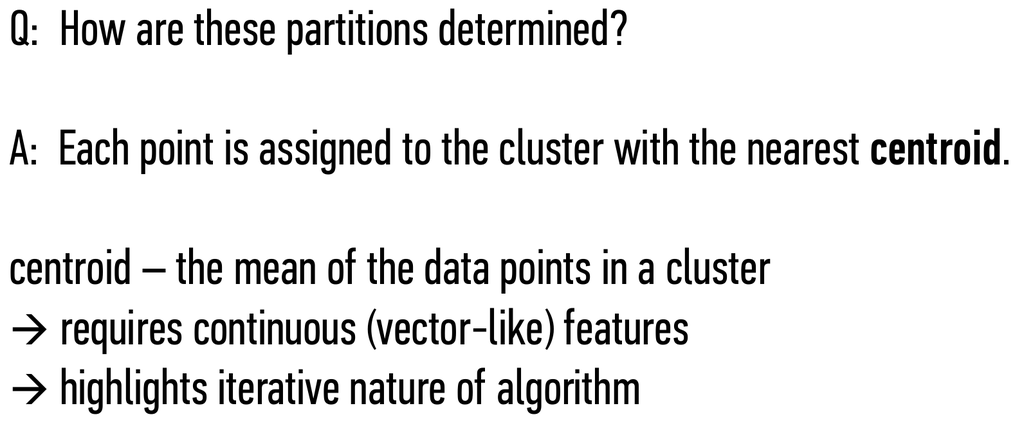

```python
Image('kmeans2.png')
```

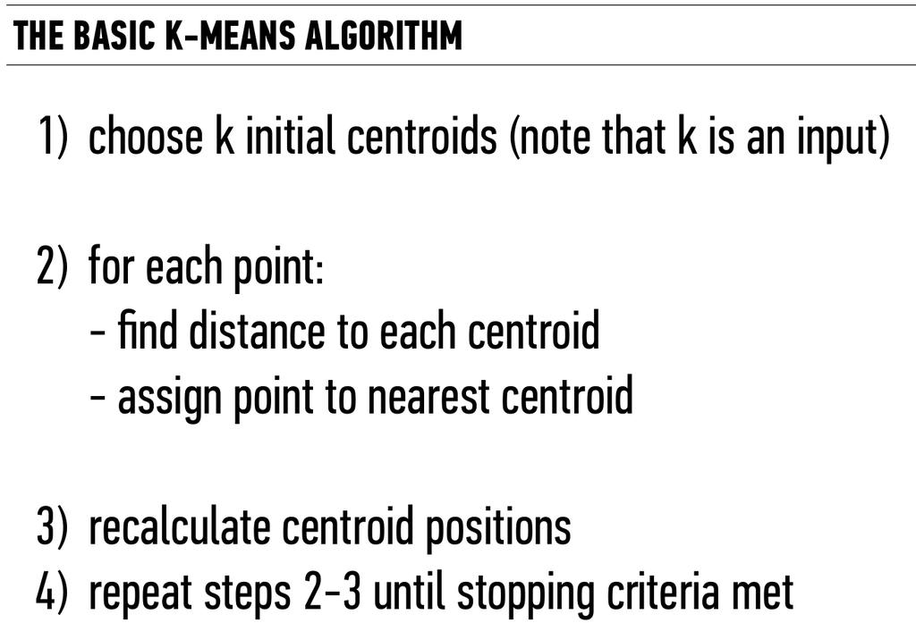

```python
Image('kmeans3.png')
```

```python
Image(url='clustering_animation.gif')
```

[figure not shown]

**KMEANS EXAMPLE: THE DIGITS DATASET**

```python
from sklearn.datasets import load_digits
#Load the digits dataset
digits = datasets.load_digits()
```

```python
print(digits.DESCR)
```

```
 Optical Recognition of Handwritten Digits Data Set

Notes
-----
Data Set Characteristics:
    :Number of Instances: 5620
    :Number of Attributes: 64
    :Attribute Information: 8x8 image of integer pixels in the range 0..16.
    :Missing Attribute Values: None
    :Creator: E. Alpaydin (alpaydin '@' boun.edu.tr)
    :Date: July; 1998

This is a copy of the test set of the UCI ML hand-written digits datasets
http://archive.ics.uci.edu/ml/datasets/Optical+Recognition+of+Handwritten+Digits

The data set contains images of hand-written digits: 10 classes where
each class refers to a digit.

Preprocessing programs made available by NIST were used to extract
normalized bitmaps of handwritten digits from a preprinted form. From a
total of 43 people, 30 contributed to the training set and different 13
to the test set. 32x32 bitmaps are divided into nonoverlapping blocks of
4x4 and the number of on pixels are counted in each block. This generates
an input matrix of 8x8 where each element is an integer in the range
0..16. This reduces dimensionality and gives invariance to small
distortions.

For info on NIST preprocessing routines, see M. D. Garris, J. L. Blue, G.
T. Candela, D. L. Dimmick, J. Geist, P. J. Grother, S. A. Janet, and C.
L. Wilson, NIST Form-Based Handprint Recognition System, NISTIR 5469,
1994.

References
----------
  - C. Kaynak (1995) Methods of Combining Multiple Classifiers and Their
    Applications to Handwritten Digit Recognition, MSc Thesis, Institute of
    Graduate Studies in Science and Engineering, Bogazici University.
  - E. Alpaydin, C. Kaynak (1998) Cascading Classifiers, Kybernetika.
  - Ken Tang and Ponnuthurai N. Suganthan and Xi Yao and A. Kai Qin.
    Linear dimensionalityreduction using relevance weighted LDA. School of
    Electrical and Electronic Engineering Nanyang Technological University.
    2005.
  - Claudio Gentile. A New Approximate Maximal Margin Classification
    Algorithm. NIPS. 2000.
```

```
[[  0.   0.   5.  13.   9.   1.   0.   0.]
 [  0.   0.  13.  15.  10.  15.   5.   0.]
 [  0.   3.  15.   2.   0.  11.   8.   0.]
 [  0.   4.  12.   0.   0.   8.   8.   0.]
 [  0.   5.   8.   0.   0.   9.   8.   0.]
 [  0.   4.  11.   0.   1.  12.   7.   0.]
 [  0.   2.  14.   5.  10.  12.   0.   0.]
 [  0.   0.   6.  13.  10.   0.   0.   0.]]
```

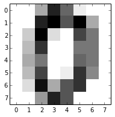

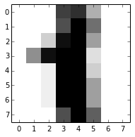

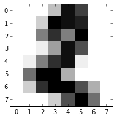

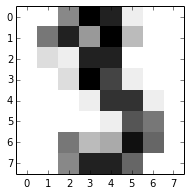

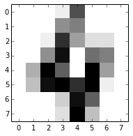

```
[None, None, None, None, None]
```

```python
#Display the digits
def plot_digit(digit_image):
    plt.figure(1, figsize=(3, 3))
    plt.imshow(digit_image, cmap=plt.cm.gray_r, interpolation='nearest')
    plt.show()

print(digits.images[0])
[plot_digit(digits.images[i]) for i in xrange(5)]
```